# MadMaize (Blanca et al. 2015): Figure5

### Convert to `genind` and `hierfstat` objects

To work with the data, we need to convert the dataset to a “genind” object.The result can then be converted to a “genind” object (from package adegent). The “genind” object can then easily be converted into a “hierfstat” (package hierfstat) object. `genind` is used to store individual genotypes,`hierfstat` is used to estimate hierarchical F-statistics for any number of hierarchical levels using the method described in Yang, R.C. (1998) Estimating hierarchical F-statistics. Evolution 52(4):950-956. It also contains functions allowing to test the significance of population differentiation.

```r
Geno_set <- Geno_group_filtered [, -c(1,2)] # Remove the first two colums and leave only SNP data
#Geno_set

ind = Geno_group_filtered$Sample # labels of the individuals
population = Geno_group_filtered$group2 # labels of the populations
Geno_set1 <- df2genind(Geno_set, ploidy = 2, ind.names = ind, pop = population, sep="") # Dataframe to genind object
Geno_set1 # combined sample ID, pop, and SNP data
```

```
## /// GENIND OBJECT /////////
##
##  // 760 individuals; 2,961 loci; 5,922 alleles; size: 19 Mb
##
##  // Basic content
##    @tab:  760 x 5922 matrix of allele counts
##    @loc.n.all: number of alleles per locus (range: 2-2)
##    @loc.fac: locus factor for the 5922 columns of @tab
##    @all.names: list of allele names for each locus
##    @ploidy: ploidy of each individual  (range: 2-2)
##    @type:  codom
##    @call: df2genind(X = Geno_set, sep = "", ind.names = ind, pop = population,
##     ploidy = 2)
##
##  // Optional content
##    @pop: population of each individual (group size range: 5-124)
```

```r
#nAll(Geno_set1) # Number of alleles per locus, commented because result is large.

Geno_set2 <- genind2hierfstat(Geno_set1) # Create hierfstat object: Pop and SNP info, no sample ID.
dim(Geno_set2)
```

```
## [1]  760 2962
```

```r
#Geno_set2_tb <- as.tibble(Geno_set2) # for easy viewing the dataset
#Geno_set2_tb
```

### Genetic diversity (observed and expected heterozygosity)

`summary` information related to compute genetic diversity. This chunck is for myself’s understanding, not the data shown in the paper.

```r
div <- summary(Geno_set1)
#div # results are too large to show
names(div)
```

```
## [1] "n"         "n.by.pop"  "loc.n.all" "pop.n.all" "NA.perc"   "Hobs"
## [7] "Hexp"
```

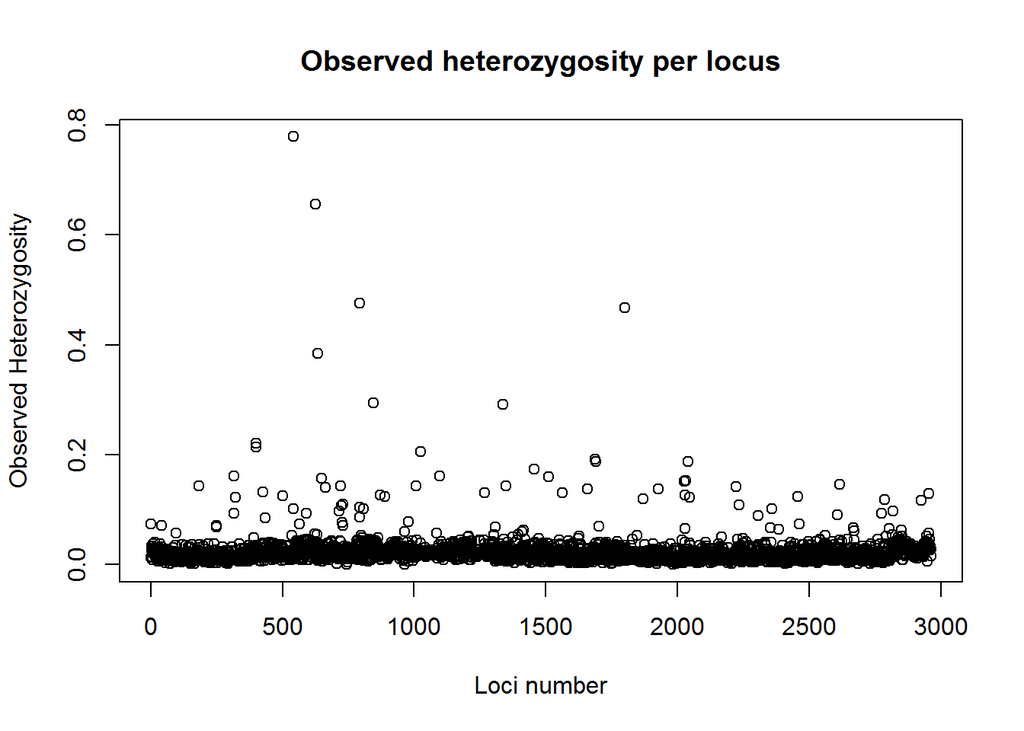

```r
# If we want to visualize the heterozygosity between expected and observed.
plot(div$Hobs, xlab="Loci number", ylab="Observed Heterozygosity",
     main="Observed heterozygosity per locus")
```

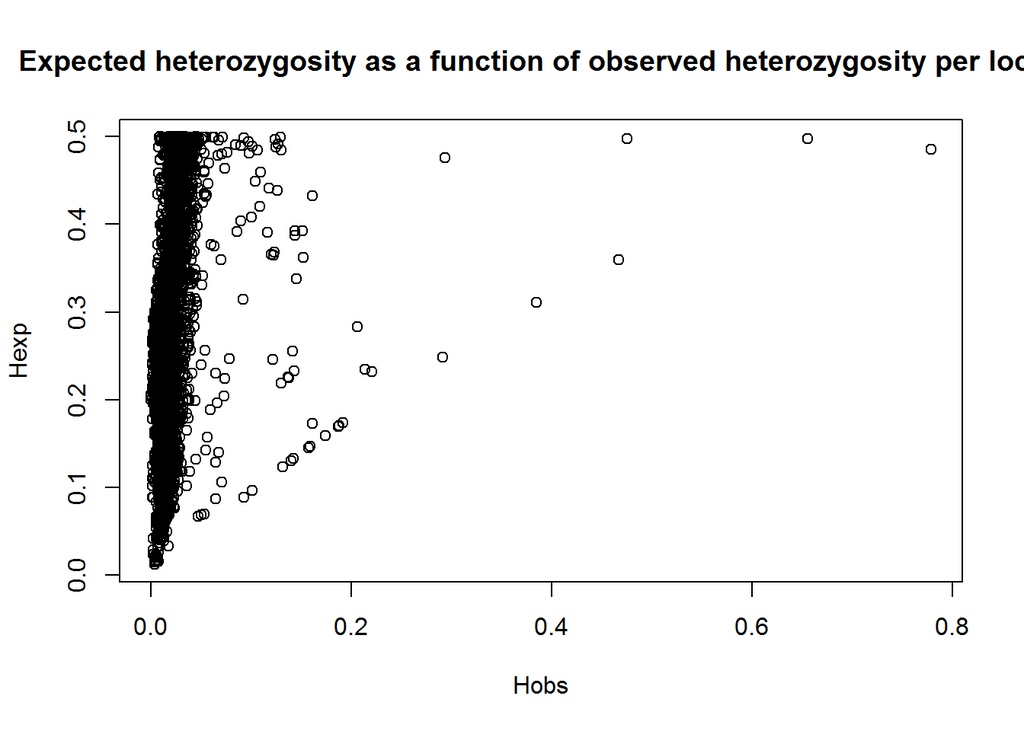

```r
plot(div$Hobs,div$Hexp, xlab="Hobs", ylab="Hexp",
     main="Expected heterozygosity as a function of observed heterozygosity per locus")
```

```r
bartlett.test(list(div$Hexp, div$Hobs)) # a test : H0: Hexp = Hobs
```

```
##
##  Bartlett test of homogeneity of variances
##
## data:  list(div$Hexp, div$Hobs)
## Bartlett's K-squared = 4935.8, df = 1, p-value < 2.2e-16
```

### Observed and expected heterozygosity: Fst based on locus

These statistics come from the package hierfstat. All the parameters are caclulated based on a single SNP site across groups `perloc` and `overall` SNP sites. This chunck is also for myself’s understanding, not the data shown in the paper.

```r
stats <- basic.stats(Geno_set1) # Dest per locus is also included in the output
stats$overall # only checking the overall stats, as the per locus result is too large
```

```
##     Ho     Hs     Ht    Dst    Htp   Dstp    Fst   Fstp    Fis   Dest
## 0.0321 0.1319 0.3372 0.2053 0.3430 0.2111 0.6088 0.6155 0.7564 0.2432
```

```r
#wc(Geno_set1) # Weir and Cockerham's estimate for Fst and Fis. No need to use this method
```

### Pairwise Fst: produce pairwise Fst matrix

`genet.dist` estimates one of several genetic distances among all pairs of populations, including Fst. The method of calculation is determined by the argument `method`. Estimate pairwise FSTs according to Nei, M. (1987) Molecular Evolutionary Genetics. Columbia University Press. **This calculation will take ~35mins to run.**

```r
FstMatrix <- genet.dist(Geno_set1, method = "Nei87")
```

### Generate nexus file for constructing neighbor-net

The output file will be used in SplitsTree4 (v 4.14.6) to generate the figure.

```r
write.nexus.dist(FstMatrix, file = "Figure5_Output/FstMatrix.nxs")
```

### Contruct an unrooted Neighbor-Net (D. Bryant and Moulton 2004) using `phangorn` package in R

We can still generate the figure by R, but it is not nicely looking. Instead, I used the SplitsTree4 method suggested by the paper to generate the final figure using the nexus file generated above.

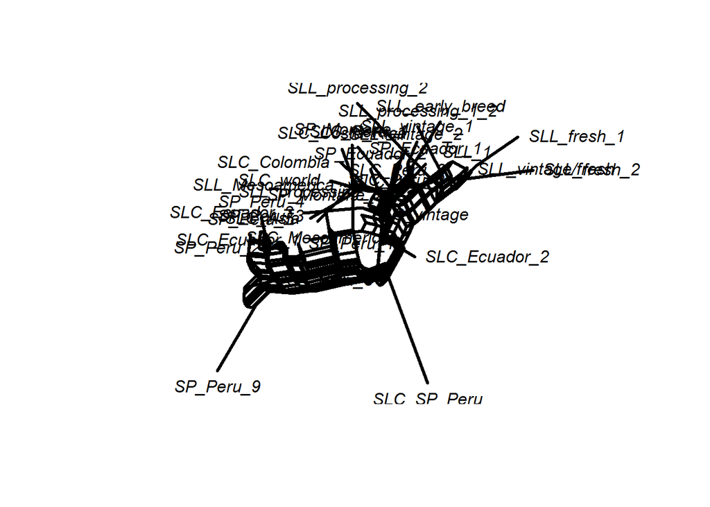

```r
nnet <- neighborNet(FstMatrix)
nnet_plot <- plot(nnet, "2D")
```